# Assignment 4

## Exercise 1

### 1.1

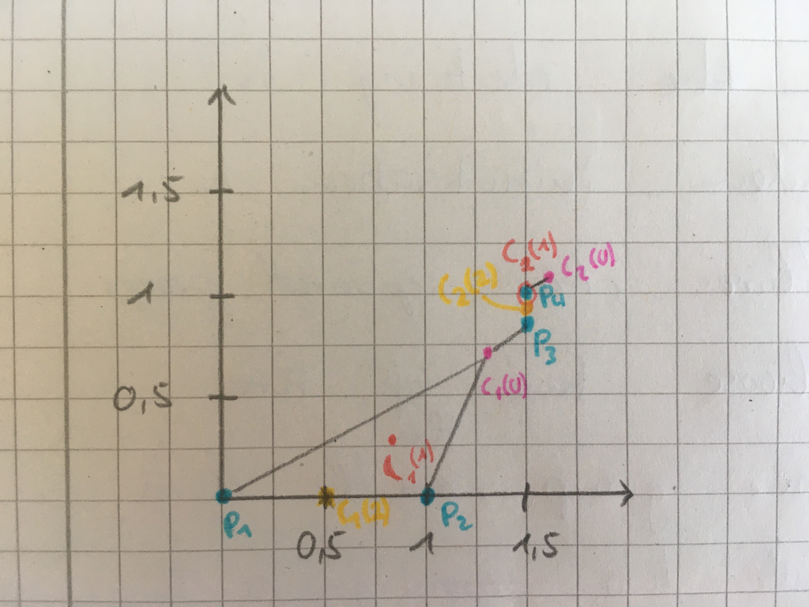

$ C_1(1) = \frac{1}{3} * \sum {0 \choose 0} {1 \choose 0} {1.5 \choose 0.8} = {0.83 \choose 0.27} $

$ C_2(1) = \frac{1}{1} * \sum {1.5 \choose 1} = {1.5 \choose 1} $

### 1.3

After recalculation of cluster centers, $P_3$ is now nearer to $C_2(1)$ then to $C_1(1)$

$ C_1(2) = \frac{1}{2} * \sum {0 \choose 0} {1 \choose 0} = {0.5 \choose 0} $

$ C_1(2) = \frac{1}{2} * \sum {1.5 \choose 0.8} {1.5 \choose 1} = {1.5 \choose 0.9} $

With the second recalculation of cluster centers, we get the final centers. No new Points will change their affiliation and the clusters won't change.

## Exercise 3

### 3.1a)

The problem is, that clustering is overdependent of the random initialisation. In our example, we have three clear seperated groups of datapoints. If we choose two of three initial centroids in one group, the third centroid needs to handle two groups. This leads to wrong clusters.

#### screenshot of initial prototypes

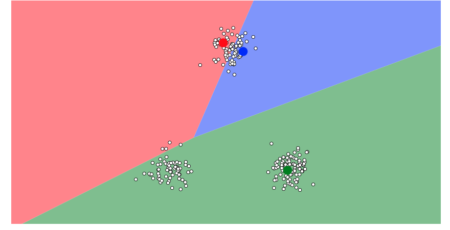

#### screenshot of final result

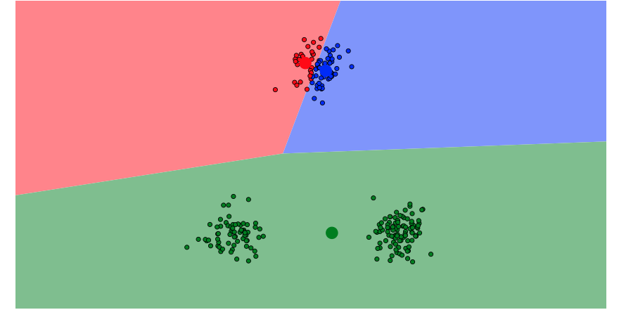

### 3.1b)

Due to the big distances between the seperated groups, it is impossible to get the centroids to the right group. Further iterations won't help, because no point of the other group appear in the cluster and the centroid can't go down.

### 3.2a)

```python
import matplotlib.pyplot as plt

def calcP(d):
    P = []
    for elem in d:
        P.append(elem/sum(d))
    return P

p = [1,3,4,6,10]

d1 = (p[0]-3)**2
d2 = (p[1]-3)**2
d3 = (p[2]-3)**2
d4 = (p[3]-3)**2
d5 = (p[4]-3)**2

d = [d1, d2,d3,d4, d5]

print("d1: ",d1)
print("d2: ",d2)
print("d3: ",d3)
print("d4: ",d4)
print("d5: ",d5)
```

```
d1:  4
d2:  0
d3:  1
d4:  9
d5:  49
```

### 3.2b)

```
P1:  0.06349206349206349 P2:  0.0 P3:  0.015873015873015872 P4:  0.14285714285714285 P5:  0.7777777777777778
```

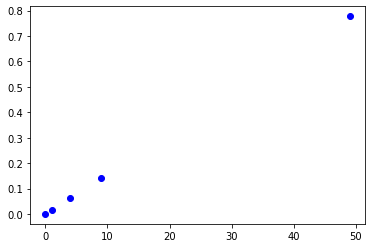

```python
P = calcP(d)
plt.plot(d,P,'bo')

print("P1: ",P[0],"P2: ", P[1],"P3: ", P[2],"P4: ", P[3],"P5: ", P[4])
plt.show()
```

## 3.2c)

```python
def calcDis(p,c):
    minDis = (p-c[0])**2
    minC = 0
    for i,ci in enumerate(c):
        d = (p-ci)**2
        if d < minDis:
            minDis = d
            minC = i
    return minDis

c = [3,10]

d = []
for pi in p:
    d.append(calcDis(pi,c))

print("min d1: ",d[0])
print("min d2: ",d[1])
print("min d3: ",d[2])
print("min d4: ",d[3])
print("min d5: ",d[4])

Pnew = calcP(d)

print("P1: ",Pnew[0])
print("P2: ",Pnew[1])
print("P3: ",Pnew[2])
print("P4: ",Pnew[3])
print("P5: ",Pnew[4])
```

```
min d1:  4
min d2:  0
min d3:  1
min d4:  9
min d5:  0
P1:  0.2857142857142857
P2:  0.0
P3:  0.07142857142857142
P4:  0.6428571428571429
P5:  0.0
```

**=> next $c_3$ = $p_4$ with $P_4$ = 0.643**

#### 3.2.c ii)

$ 14 * P_1 \ = \ 4.06 $ **=> 4 times**

$ 14 * P_3 \ = \ 0.994 $ **=> 1 time**

$ 14 * P_4 \ = \ 8.96 $ **=> 9 times**

### 3.3.a)

The algorithm choose the point using the probability based on size / squared distance.

### 3.3b)

If we take the example from the video, we can see that the highest distance can lead to unfavourable clusters. E. g. The first random point starts in the top left corner. The second would be in the lower left corner. the third would be in the upper right corner. Now we can see, that in the two top clusters would be not that much point than we would expect. Further if the first random point is not in the near of the center, we have no opportunity to get another cluster in the center.